# Comparing Classifiers on Online Shopper Purchase Intent

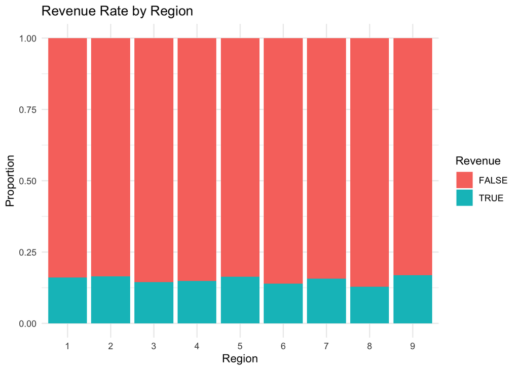

```
##
##  Pearson's Chi-squared test
##
## data:  table(df$Region, df$Revenue)
## X-squared = 9.2528, df = 8, p-value = 0.3214
```

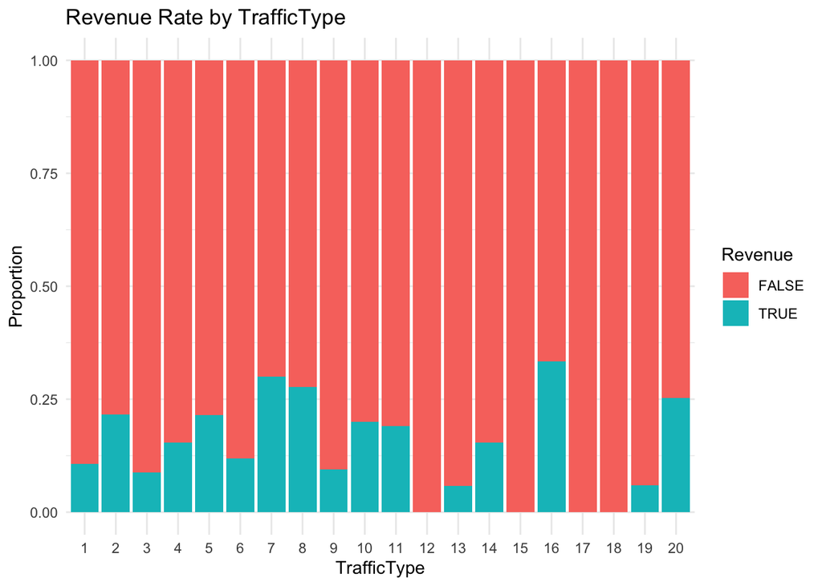

```
##
##  Pearson's Chi-squared test
##
## data:  table(df$TrafficType, df$Revenue)
## X-squared = 373.15, df = 19, p-value < 2.2e-16
```

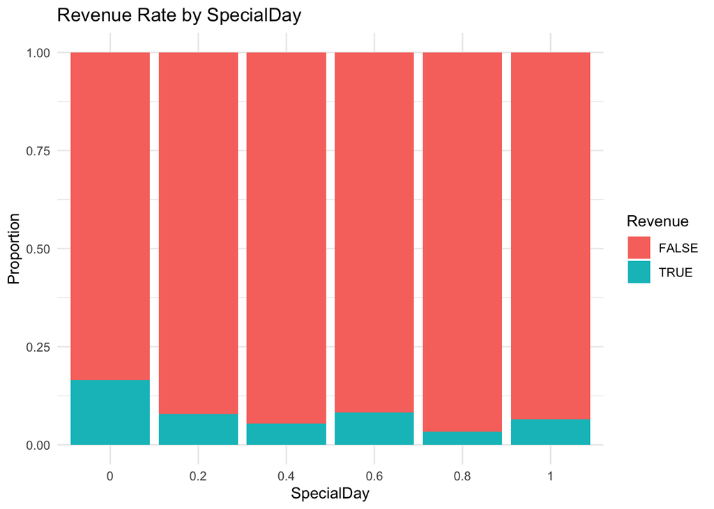

```
##
##  Pearson's Chi-squared test
##
## data:  table(df$SpecialDay, df$Revenue)
## X-squared = 96.077, df = 5, p-value < 2.2e-16
```

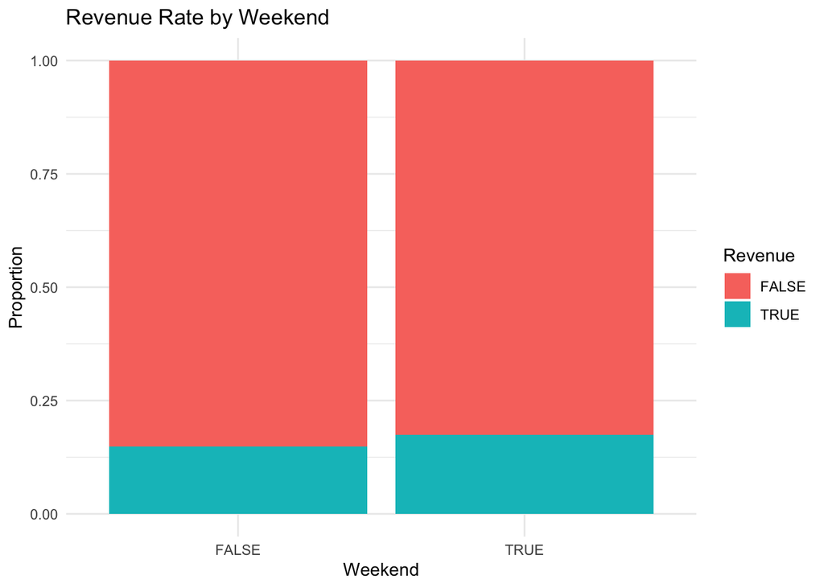

```
##
##  Pearson's Chi-squared test with Yates' continuity correction
##
## data:  table(df$Weekend, df$Revenue)
## X-squared = 10.391, df = 1, p-value = 0.001266
```

The chi-squared tests confirm what the proportional bar charts suggest visually: most nominal variables show a statistically significant association with Revenue, with Region as the one clear exception.

Statistically significant at the p < 0.05 level:

- Month (x^2 = 384.93, p < 2.2e-16): the strongest result in the set, consistent with the clear seasonal variation seen in the bar chart (November standing out with the highest conversion proportion, February the lowest).
- VisitorType (x^2 = 135.25, p < 2.2e-16): interestingly, New_Visitor shows the highest conversion proportion of the three groups, with Returning_Visitor actually the lowest, which runs counter to an assumption that familiarity with the site would drive more purchases.
- TrafficType (x^2 = 373.15, p < 2.2e-16): significant, though with real spread in conversion rate across categories (TrafficType 16 and 7 notably higher than others).
- SpecialDay (x^2 = 96.077, p < 2.2e-16): significant despite showing no consistent trend in the bar chart, supporting the earlier decision to treat it as nominal rather than ordinal; conversion is actually highest at SpecialDay = 0, not near the special day itself.
- OperatingSystems (x^2 = 75.027, p = 1.416e-13): significant, though the bar chart shows fairly modest differences in conversion proportion across categories.
- Browser (x^2 = 27.715, p = 0.006088): significant, though a weaker relationship than the others, with most categories clustered closely around a similar conversion rate.
- Weekend (x^2 = 10.391, p = 0.001266): significant, with weekend sessions showing a modestly higher conversion rate than weekday sessions.

Not statistically significant:

- Region (x^2 = 9.2528, p = 0.3214): the one nominal variable that fails to show a significant relationship with Revenue. The bar chart confirms this visually: conversion proportion is nearly flat across all nine regions, suggesting geography isn’t a meaningful driver of purchase behavior in this dataset.

Given Region shows no significant relationship with the target, it will be excluded, while the remaining nominal variables all show evidence of a meaningful relationship with purchase behavior and will be retained.

### Decision Summary

For variable management, I will drop Region and convert OperatingSystems, Browser, and TrafficType to factors. SpecialDay will be treated as nominal.

For kNN and logistic regression, the following nominal and logical variables will be dummy encoded: OperatingSystems, Browser, TrafficType, SpecialDay, Month, VisitorType. Because Weekend is already logical, it does not need encoding. All numeric variables will be log1p transformed, followed by z-score standardization for the kNN set specifically.

For feature engineering, nominal variables with rare categories (under 1% of total) will be collapsed into an “Other” bucket. To reduce multicollinearity in kNN and logistic regression, I will derive two engineered features: an average time per product page (ProductRelated_Duration / ProductRelated, with zero-page sessions set to zero) and a combined disengagement score (the mean of BounceRates and ExitRates).

To address class imbalance, I will apply random undersampling of the majority class when training the kNN and logistic regression models, and use case weights with boosting for the decision tree.

## Data Cleaning and Preparation

In this section, I will clean the data, implementing the decisions described in the EDA section. Note that I will only perform overall cleaning and cleaning specific to logistic regression at this stage. This is because completeing the cleaning for kNN requires z-score standardization, and computing that standardization on the full dataset would risk data leakage, since the standardization parameters (mean and standard deviation) would be informed by rows that later become part of the test set. Thus, I will perform the overall clean, then clean for logistic regression (and part of kNN), then split the data, and only then clean fully for kNN using standardization parameters derived from the training set alone. The decision tree does not require any cleaning beyond the overall clean, since the algorithm can handle skewed and non-standardized variables.

### Overall Cleaning

First, as described in the EDA, I will drop Region, because it shows no significant relationship with the target, and is thus useless to my models.

```r
df$Region <- NULL
```

Next, I will transform OperatingSystems, Browser, and TrafficType to factors.

```r
df$OperatingSystems <- as.factor(df$OperatingSystems)
df$Browser <- as.factor(df$Browser)
df$TrafficType <- as.factor(df$TrafficType)
df$SpecialDay <- as.factor(df$SpecialDay)
```

As the target is logical TRUE/FALSE, I also need to transform it to a factor. This is because many of my modeling and evaluation functions in R, including knn(), glm(), C5.0(), and roc(), expect categorical outcomes to be represented as factors rather than logicals.

```r
df$Revenue <- factor(df$Revenue, labels = c("FALSE", "TRUE"))
```

Next, I will apply a 1% frequency threshold, and collapse anything below it into “Other” categories.

```r
vars_to_bucket <- c("OperatingSystems", "Browser", "TrafficType", "SpecialDay")

for (i in vars_to_bucket) {
  counts <- table(df[[i]])
  proportions <- counts / sum(counts)
  rare_levels <- names(proportions[proportions < 0.01]) #Finding the rare levels

  df[[i]] <- as.character(df[[i]]) #For the column of the name (converting from factor)
  df[[i]][df[[i]] %in% rare_levels] <- "Other" #Return if there is rare levels, if so make it other
  df[[i]] <- as.factor(df[[i]]) #Convert back into factor
}

#Checking
table(df$OperatingSystems)
```

```
##
##     1     2     3     4 Other
##  2585  6601  2555   478   111
```

```r
table(df$Browser)
```

```
##
##     1    10     2     4     5     6     8 Other
##  2462   163  7961   736   467   174   135   232
```

```r
table(df$TrafficType)
```

```
##
##     1    10    11    13     2    20     3     4     5     6     8 Other
##  2451   450   247   738  3913   198  2052  1069   260   444   343   165
```

```r
table(df$SpecialDay)
```

```
##
##     0   0.2   0.4   0.6   0.8     1
## 11079   178   243   351   325   154
```

#### Missing and Imputation Exercise

As noted in the EDA, there is no missing data or placeholders to impute to remove.

### Algorithm-Specific Cleaning

In this section, I will copy the data into three different datasets, one for each algorithm, and shape and clean the data for each algorithm accordingly.

```r
df_logreg <- df
df_knn <- df
df_tree <- df
```

### Cleaning for Logistic Regression

#### Feature Engineering for Multicollinearity

As noted, I will derive new features by combining each correlated pair, then drop both original variables from each pair in the kNN and logistic regression sets. This produces a single column that captures the combined signal of the two, rather than retaining both correlated variables separately.

```r
#ProductRelated_AvgTime: average time spent per product-related page
df_knn$ProductRelated_AvgTime <- ifelse(df_knn$ProductRelated == 0, 0, #Creates a new column, sets the value to zero already if ProductRelated is zero
                                          df_knn$ProductRelated_Duration / df_knn$ProductRelated) #if not, divides duration by number of product pages viewed, so it is an everage per page

df_logreg$ProductRelated_AvgTime <- ifelse(df_logreg$ProductRelated == 0, 0,
                                             df_logreg$ProductRelated_Duration / df_logreg$ProductRelated)

#Disengagement_Score: average of BounceRates and ExitRates
df_knn$Disengagement_Score <- (df_knn$BounceRates + df_knn$ExitRates) / 2 #Row-wise average column
df_logreg$Disengagement_Score <- (df_logreg$BounceRates + df_logreg$ExitRates) / 2

#Drop the original source variables
df_knn <- df_knn %>% select(-ProductRelated, -ProductRelated_Duration, -BounceRates, -ExitRates)
df_logreg <- df_logreg %>% select(-ProductRelated, -ProductRelated_Duration, -BounceRates, -ExitRates)
```

#### Transformation of Numeric Variables

Now, I will log1p transform the numeric variables: Administrative, Administrative_Duration, Informational, Informational_Duration, ProductRelated_AvgTime, Disengagement_Score, and PageValues. I do this because these variables are heavily right-skewed, and a log transformation compresses the long tail of extreme values, bringing each variable closer to a shape that better satisfies the assumptions of logistic regression and improves the reliability of distance calculations in kNN. I use log1p() specifically (log(x + 1)) rather than a plain log transform, since several of these variables contain true zero values that would otherwise produce undefined results. As noted, I will only do this for the kNN and logistic regression sets, since the decision tree can handle skewed variables natively and does not require this transformation.

#### Encoding

Now for as mentioned in the EDA, we will dummy encode Month, VisitorType, OperatingSystems, Browser, TrafficType, SpecialDay for the logistic regression and kNN sets. This converts each nominal variable into a set of binary columns, one per category level, so that these algorithms can use the information numerically rather than as unordered category labels.

```r
vars_to_encode <- c("Month", "VisitorType", "OperatingSystems", "Browser", "TrafficType", "SpecialDay")

#kNN
for (v in vars_to_encode) {
  var_levels <- levels(df_knn[[v]])
  var_levels <- var_levels[-1] #Dropping the first level

  for (lvl in var_levels) {
    col_name <- paste0(v, "_", lvl) #joins the variable and the level into a new column
    df_knn[[col_name]] <- ifelse(df_knn[[v]] == lvl, 1, 0) #If the current variable's value is the level, get a 1
  }

  df_knn[[v]] <- NULL #Get rid of initial column
}

#Logistic Regression
for (v in vars_to_encode) {
  var_levels <- levels(df_logreg[[v]])
  var_levels <- var_levels[-1]

  for (lvl in var_levels) {
    col_name <- paste0(v, "_", lvl)
    df_logreg[[col_name]] <- ifelse(df_logreg[[v]] == lvl, 1, 0)
  }

  df_logreg[[v]] <- NULL
}
```

### Cleaning for Decision Tree

Minimal additional cleaning is required for the decision tree beyond the overall clean already applied. C5.0 splits directly on categorical variables in their native factor form, so it does not require one-hot encoding, and it makes no distributional assumptions, so the skewed numeric variables do not need a log transform. It is also not sensitive to feature scale, so z-score standardization is unnecessary, and since it evaluates one variable at a time when selecting splits, it is not meaningfully affected by the multicollinearity addressed for logistic regression and kNN, so the original ProductRelated, ProductRelated_Duration, BounceRates, and ExitRates variables are retained rather than replaced with engineered features.

The rare-category grouping applied to OperatingSystems, Browser, TrafficType, and SpecialDay was carried over to df_tree as well, even though C5.0 is less prone to the sparse-dummy-column instability that motivated this step for logistic regression and kNN. This keeps category definitions consistent across all three model-specific datasets and avoids retaining extremely small categories (some with only a handful of observations) that could still produce unstable, overfit splits in the tree. df_tree therefore reflects the state of the data after Overall Cleaning and rare-category grouping, with Region dropped and categorical variables converted to factors, but no log transformation, feature engineering, encoding, or standardization applied. Class imbalance for the decision tree is addressed separately in the Data Splitting section using case weights, applied after the train/test split.

The only additional cleaning needed for the Decision Tree data is to make all logicals factors, as C5.0 cannot digest logicals.

```r
#Identifying any logical columns in df_tree
logical_cols <- names(df_tree)[sapply(df_tree, is.logical)]
logical_cols
```

```
## [1] "Weekend"
```

```r
df_tree$Weekend <- as.factor(df_tree$Weekend)
```

### Data Splitting

Now, I am splitting my data. I am splitting the data into training and test sets for each of the three model-specific datasets using the same row indices across all three. Because the indices are identical, each test set contains the exact same underlying sessions in the same order, just represented with each model’s own cleaned features. This makes the three models’ predictions directly comparable, and allows the ensemble to be evaluated on any one of the three test sets (since their Revenue values are identical). I am using stratified splitting, which splits each class (TRUE and FALSE Revenue) separately before combining them, ensuring that both the training and test sets preserve the same 84.5% / 15.5% class ratio found in the full dataset, rather than risking an uneven split by chance given how imbalanced the target variable is.

```r
set.seed(100)

#Getting row indices for each class
true_indices <- which(df$Revenue == "TRUE")
false_indices <- which(df$Revenue == "FALSE")

#Shuffling each set of indices
true_indices <- sample(true_indices)
false_indices <- sample(false_indices)

#Calculating how many rows go into training (80%) for each class
n_true_train <- round(0.8 * length(true_indices))
n_false_train <- round(0.8 * length(false_indices))

#Splitting each class into train/test
train_true <- true_indices[1:n_true_train]
test_true <- true_indices[(n_true_train + 1):length(true_indices)]

train_false <- false_indices[1:n_false_train]
test_false <- false_indices[(n_false_train + 1):length(false_indices)]

#Combining
train_index <- c(train_true, train_false)
test_index <- c(test_true, test_false)

#Applying to dataframes
train_knn <- df_knn[train_index, ]
test_knn  <- df_knn[test_index, ]

train_logreg <- df_logreg[train_index, ]
test_logreg  <- df_logreg[test_index, ]

train_tree <- df_tree[train_index, ]
test_tree  <- df_tree[test_index, ]
```

### Cleaning for kNN: Z-score Standardization

I will now complete the final cleaning step for the kNN set: z-score standardization. I will use train_knn’s mean and standard deviation, and apply them to both the train and test kNN sets. This is because computing standardization parameters from the full dataset (or from the test set) would leak information about the test set’s distribution into the training process. Using only the training set’s mean and standard deviation, and applying those same fixed values to the test set keeps the test set truly held out while still ensuring both sets are on a comparable scale for kNN’s distance calculations.

```r
#Identifying the numeric columns
numeric_cols <- c("Administrative_log", "Administrative_Duration_log",
                   "Informational_log", "Informational_Duration_log",
                   "ProductRelated_AvgTime_log", "Disengagement_Score_log",
                   "PageValues_log")

#Computing mean and sd
train_means <- sapply(train_knn[, numeric_cols], mean)
train_sds <- sapply(train_knn[, numeric_cols], sd)

#Standardizing
for (col in numeric_cols) {
  train_knn[[col]] <- (train_knn[[col]] - train_means[col]) / train_sds[col]
}

#Apply to test_knn
for (col in numeric_cols) {
  test_knn[[col]] <- (test_knn[[col]] - train_means[col]) / train_sds[col]
}
```

## Post-transform Exploration

Now that the kNN set has been standardized, I will use it to run three exploratory checks: outlier detection, cluster analysis, and PCA. Outlier detection is run here because standardizing does not change a row’s relative position within its distribution, so the results apply equally to the logistic regression set.

Clustering and PCA are also run on the kNN set’s standardized features, since both require scaled input. Depending on what PCA reveals about the redundancy in my numeric and encoded features, I may use the resulting principal components as replacement features specifically for the kNN model. kNN benefits from this in a way the other two models do not, because distance calculations become less meaningful as dimensionality increases, since points tend to appear roughly equidistant from one another in high-dimensional sparse space. Reducing this to a smaller number of components that capture most of the variance directly addresses that weakness.

I will not apply PCA to the logistic regression set, since principal components are not individually interpretable as business variables, which conflicts with logistic regression’s role in this project of producing coefficients a stakeholder can act on directly. PCA does not apply to the decision tree at all, since it does not benefit from dimensionality reduction.

#### Outlier Check

Now, I will perform a z-score outlier check. I will do this by detecting observations that are more than 3 standard deviations from the mean (either above or below the mean), which is a standard cutoff for outliers. This check requires log-transformed, standardized numeric data to be meaningful, since a raw-scale z-score check would be distorted by the skew. I will run this detection on the kNN set, which has already been log-transformed and standardized, and apply the same results or any decisions to the logistic regression set, since it shares the same underlying log-transformed values and standardizing does not change a row’s position relative to the rest of its distribution. I will not apply this check to the decision tree set, since it retains raw, untransformed numeric variables, and C5.0’s split-based structure is inherently less sensitive to extreme values.

```r
#Making empty matrix with T/F whether or not its outlier
outlier_flags_train <- matrix(FALSE, nrow = nrow(train_knn), ncol = length(numeric_cols)) #Starts with FALSE
outlier_flags_test <- matrix(FALSE, nrow = nrow(test_knn), ncol = length(numeric_cols))

colnames(outlier_flags_train) <- numeric_cols #Setting colnames to the numeric variables
colnames(outlier_flags_test) <- numeric_cols

#Loops through and flags outliers
for (col in numeric_cols) {
  outlier_flags_train[, col] <- abs(train_knn[[col]]) > 3 #Mark TRUE if the absolute value is more than 3
  outlier_flags_test[, col] <- abs(test_knn[[col]]) > 3
}

#Total number of outlier values found per column
colSums(outlier_flags_train)
```

```
##          Administrative_log Administrative_Duration_log
##                           0                           0
##           Informational_log  Informational_Duration_log
##                         202                         144
##  ProductRelated_AvgTime_log     Disengagement_Score_log
##                         604                         557
##              PageValues_log
##                         106
```

```r
colSums(outlier_flags_test)
```

```
##          Administrative_log Administrative_Duration_log
##                           0                           0
##           Informational_log  Informational_Duration_log
##                          58                          40
##  ProductRelated_AvgTime_log     Disengagement_Score_log
##                         160                         151
##              PageValues_log
##                          29
```

```r
#Number of rows with at least one outlier value
rows_with_outliers_train <- rowSums(outlier_flags_train) > 0
rows_with_outliers_test <- rowSums(outlier_flags_test) > 0

sum(rows_with_outliers_train)
```

```
## [1] 1005
```

```r
sum(rows_with_outliers_test)
```

```
## [1] 272
```

Running the outlier check on the standardized kNN training and test sets flags 1005 of 9864 training rows (~10.2%) and 272 of 2466 test rows (~11.0%) with at least one value beyond 3 standard deviations. Administrative_log and Administrative_Duration_log show zero flagged values, while the two engineered features, ProductRelated_AvgTime_log and Disengagement_Score_log, show the most.

Consistent with the decision made earlier in this notebook, I am retaining these flagged observations rather than removing them. At roughly 10% of the data, these are not rare, isolated anomalies but a normal feature of this dataset’s skewed behavior, and the earlier data quality checks confirmed no evidence of corrupted or impossible values. Removing them would risk disproportionately discarding legitimate high-engagement sessions, which are precisely the kind of session most associated with Revenue = TRUE given PageValues’ established relationship with conversion. This would work directly against the minority class I am already taking separate steps (undersampling) to preserve. This check therefore serves as a diagnostic confirming the scale of extreme values present.

#### Clustering Exploration

I will now explore clustering with k-means clustering. This is an unsupervised method that groups observations into subgroups based on similarity, without using the target variable, allowing me to check whether the data contains natural segments of browsing behavior. I will only do this on my numeric variables, because k-means relies on Euclidean distance, and including the one-hot encoded categorical dummy variables alongside the numeric variables would distort that distance calculation, since binary dummy columns behave differently in distance terms than continuous standardized variables and would disproportionately influence cluster assignment.

I am performing this clustering exploration on the kNN set specifically, since it is the only one of my three datasets that is both log-transformed and standardized. Since cluster membership is derived using Euclidean distance, I’m also only adding it as an engineered feature to the kNN set, where that distance-based logic is directly relevant to the model.

First, I will begin by using the elbow method to determine my k, or amount of clusters. This computes k-means clustering for a range of possible k values and plots the total within-cluster sum of squares for each; the point where this curve bends and flattens indicates the k value beyond which adding more clusters yields diminishing returns.

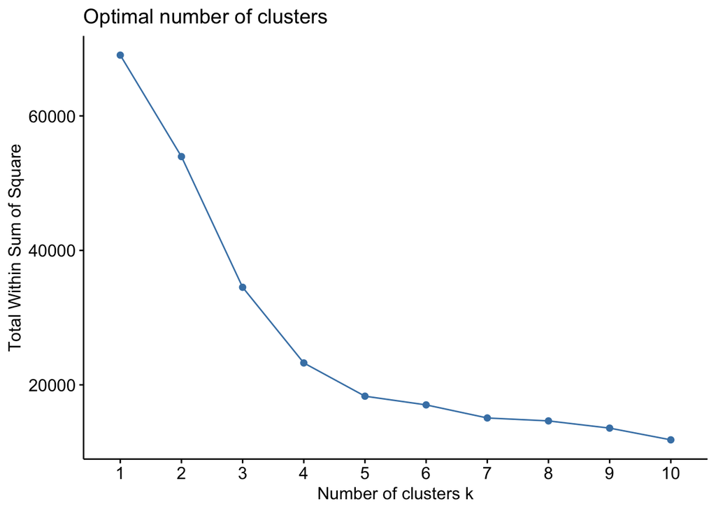

```r
set.seed(200)

cluster_input <- train_knn[, numeric_cols]

fviz_nbclust(cluster_input, kmeans, method = "wss")
```

This chart shows k=4 as where the line flattens substantially. Thus, I will now conduct k means clustering with k=4.

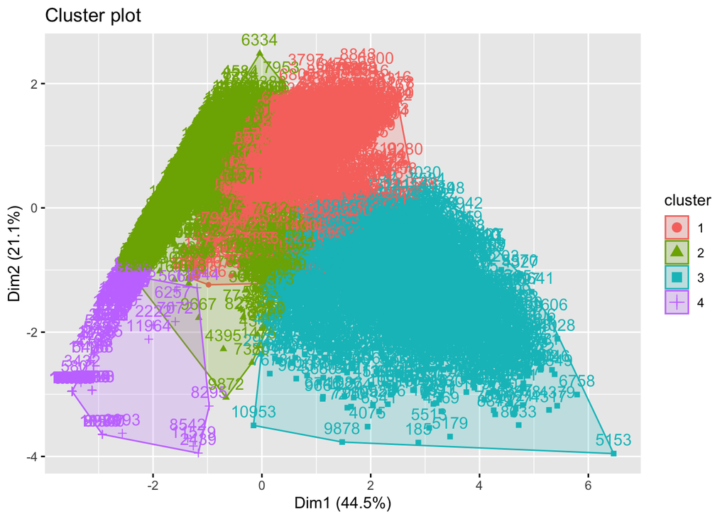

```r
fviz_cluster(final, data = cluster_input)
```

Visualizing the four clusters along the first two principal components (which together explain ~65.6% of the variance in the numeric features) shows moderate separation. Clusters 2 (green) and 4 (purple) sit distinctly on the left side of the plot, with cluster 4 forming the most visually distinct, compact group. Clusters 1 (red) and 3 (teal) show substantial overlap in the middle of the plot, though cluster 3 extends further to the right along Dim1, suggesting it captures sessions with higher values along the underlying pattern Dim1 represents. The point labels visible in the plot are row numbers.

Now that the clusters have been formed, I will examine what each cluster actually represents by calculating the average value of each numeric variable within each cluster. This will let me interpret each cluster in terms of actual behavior rather than treating cluster membership as an unlabeled group. I will then cross-tabulate cluster membership against Revenue to check whether any cluster is disproportionately associated with converting sessions. If a cluster shows a meaningfully higher or lower purchase rate than the overall ~15.5% baseline, that would suggest cluster membership carries predictive signal and is worth considering as an engineered feature. If purchase rates are roughly similar across all four clusters, that would indicate the clusters reflect browsing behavior patterns that are not strongly tied to conversion, and I will not use cluster membership as a feature.

```r
#Average value of each numeric variable per cluster
train_knn %>%
  mutate(Cluster = final$cluster) %>%
  group_by(Cluster) %>%
  summarise(across(all_of(numeric_cols), mean))
```

```
## # A tibble: 4 × 8
##   Cluster Administrative_log Administrative_Duration_log Informational_log
##     <int>              <dbl>                       <dbl>             <dbl>
## 1       1              0.774                       0.892            -0.410
## 2       2             -0.870                      -0.935            -0.406
## 3       3              0.859                       0.807             1.92
## 4       4             -0.905                      -0.971            -0.451
## # ℹ 4 more variables: Informational_Duration_log <dbl>,
## #   ProductRelated_AvgTime_log <dbl>, Disengagement_Score_log <dbl>,
## #   PageValues_log <dbl>
```

```r
#Tabling with Revenue
table(final$cluster, train_knn$Revenue)
```

```
##
##     FALSE TRUE
##   1  2684  721
##   2  3689  380
##   3  1316  422
##   4   649    3
```

Cross-tabulating cluster membership against Revenue reveals meaningful differences in conversion rate across clusters. Against an overall baseline conversion rate of ~15.5%, Cluster 3 converts at the highest rate (~24.3%), followed by Cluster 1 (~21.2%), both abive baseline. Cluster 2 converts below baseline (~9.3%), and Cluster 4 stands out sharply, with a conversion rate of just ~0.5% (3 of 652 sessions), suggesting this cluster captures a distinct group of sessions that almost never result in a purchase.

This result, combined with the cluster means, indicates that cluster membership does carry meaningful signal relating to purchase behavior. Given this, I will add cluster membership as an engineered categorical feature for the kNN model.

```r
#Creating a new column officially storing the cluster assignations for the train set
train_knn$Cluster <- as.factor(final$cluster)

#Getting the centroids
centroids <- final$centers

#Assigning each test row to its closest centroid
assign_cluster <- function(row, centroids) { #New function, taking the row and the centroids
  distances <- apply(centroids, 1, function(centroid) {
    sqrt(sum((row - centroid)^2)) #Taking the euclidean distance
  })
  return(which.min(distances)) #finding the shortest distance
}

test_clusters <- apply(test_knn[, numeric_cols], 1, assign_cluster, centroids = centroids) #apply my function to the whole set
test_knn$Cluster <- as.factor(test_clusters) #add this as a new column
```

[output not shown]

[output not shown]

Now the clusters are assigned into to columns in the test and train set. Because the clusters are nominal, I need to dummy encode them:

```r
#Cluster 2
train_knn$Cluster_2 <- ifelse(train_knn$Cluster == "2", 1, 0)
test_knn$Cluster_2 <- ifelse(test_knn$Cluster == "2", 1, 0)

#Cluster 3
train_knn$Cluster_3 <- ifelse(train_knn$Cluster == "3", 1, 0)
test_knn$Cluster_3 <- ifelse(test_knn$Cluster == "3", 1, 0)

#Cluster 4
train_knn$Cluster_4 <- ifelse(train_knn$Cluster == "4", 1, 0)
test_knn$Cluster_4 <- ifelse(test_knn$Cluster == "4", 1, 0)

#Dropping the original Cluster column
train_knn$Cluster <- NULL
test_knn$Cluster <- NULL
```

Now, the cluster assignation is added as a nominal variable in the kNN set.

#### Dimensionality Reduction (PCA)

Now, I will perform dimensionality reduction to further optimize my data. I will do this on the kNN set, since it is the only one of my three model-specific datasets that has already been standardized, and because kNN is likely to benefit from a reduced feature space given the sparsity introduced by one-hot encoding. Logistic regression could technically benefit from PCA as well, since it can further reduce noise, but I am not applying it there: logistic regression does not suffer from dimensionality the way distance-based kNN does, and I have already addressed the main multicollinearity concern directly through feature engineering. I will do this on the numeric columns, because because PCA relies on variance calculations that are only meaningful for continuous variables.

I will do this via PCA, which is an unsupervised technique that transforms the original correlated features into a smaller set of new, uncorrelated components, ordered by how much variance in the data each one explains.

```r
pca_result <- prcomp(train_knn[, numeric_cols], center = TRUE, scale. = TRUE)

#Proportion of variance explained
summary(pca_result)
```

```
## Importance of components:
##                           PC1    PC2   PC3    PC4     PC5     PC6     PC7
## Standard deviation     1.7654 1.2148 1.058 0.9248 0.52744 0.28607 0.26963
## Proportion of Variance 0.4452 0.2108 0.160 0.1222 0.03974 0.01169 0.01039
## Cumulative Proportion  0.4452 0.6561 0.816 0.9382 0.97792 0.98961 1.00000
```

Looking at the proportion of variance explained per component, PC1, PC2, and PC3 each carry a substantial share (44.5%, 21.1%, and 16.0% respectively), while PC4 drops to 12.2% and the remaining components (PC5–PC7) each explain less than 4% individually. Given this, I will retain the first 4 principal components, capturing the large majority of the variance in the numeric feature set while reducing dimensionality from 7 original variables down to 4 uncorrelated components.

I will create a kNN set with the PCA reduced variables replacing the numeric variables, and retain one without. Thus, I can test which model performs better, and which to add to my overall ensemble.

```r
#Keep only the first 4
train_pca <- as.data.frame(pca_result$x[, 1:4])
colnames(train_pca) <- paste0("PC", 1:4) #renaming columns

test_pca <- as.data.frame(as.matrix(test_knn[, numeric_cols]) %*% pca_result$rotation[, 1:4])
colnames(test_pca) <- paste0("PC", 1:4)

#Making PCA-reduced copy
train_knn_pca <- train_knn
test_knn_pca <- test_knn

train_knn_pca <- cbind(train_knn_pca, train_pca) #adding the pca columns
test_knn_pca <- cbind(test_knn_pca, test_pca)

train_knn_pca <- train_knn_pca[, !(names(train_knn_pca) %in% numeric_cols)] #Getting rid of numeric columns
test_knn_pca <- test_knn_pca[, !(names(test_knn_pca) %in% numeric_cols)]
```

#### Class Imbalance Strategy

As noted, I will manage the class imbalance for the kNN and logistic regression sets via random undersampling of the majority class.

```r
set.seed(500)

#Separating true and false
majority_knn <- train_knn[train_knn$Revenue == "FALSE", ]
minority_knn <- train_knn[train_knn$Revenue == "TRUE", ]

#Undersampling
majority_knn_under <- majority_knn[sample(1:nrow(majority_knn), size = nrow(minority_knn)), ]

#Combining
train_knn_balanced <- rbind(majority_knn_under, minority_knn)

#Shuffling
train_knn_balanced <- train_knn_balanced[sample(1:nrow(train_knn_balanced)), ]

#Checking
table(train_knn_balanced$Revenue)
```

```
##
## FALSE  TRUE
##  1526  1526
```

```r
set.seed(543)

#Same for PCA set
majority_knn_pca <- train_knn_pca[train_knn_pca$Revenue == "FALSE", ]
minority_knn_pca <- train_knn_pca[train_knn_pca$Revenue == "TRUE", ]

majority_knn_pca_under <- majority_knn_pca[sample(1:nrow(majority_knn_pca), size = nrow(minority_knn_pca)), ]

train_knn_pca_balanced <- rbind(majority_knn_pca_under, minority_knn_pca)

train_knn_pca_balanced <- train_knn_pca_balanced[sample(1:nrow(train_knn_pca_balanced)), ]

table(train_knn_pca_balanced$Revenue)
```

```
##
## FALSE  TRUE
##  1526  1526
```

```r
set.seed(600)
# Same for logistic regression
majority_logreg <- train_logreg[train_logreg$Revenue == "FALSE", ]
minority_logreg <- train_logreg[train_logreg$Revenue == "TRUE", ]

majority_logreg_under <- majority_logreg[sample(1:nrow(majority_logreg), size = nrow(minority_logreg)), ]

train_logreg_balanced <- rbind(majority_logreg_under, minority_logreg)
train_logreg_balanced <- train_logreg_balanced[sample(1:nrow(train_logreg_balanced)), ]

table(train_logreg_balanced$Revenue)
```

```
##
## FALSE  TRUE
##  1526  1526
```

Now that the data is cleaned for each set and the class imbalance has been managed, I will move onto modeling.

## Modeling

### kNN

The first model that I will build is a kNN, or k-nearest neighbors model. This is an instance-based, non-parametric classification algorithm that predicts a session’s outcome by identifying the k most similar sessions in the training data (based on distance across all features) and taking a majority vote among their outcomes. Unlike logistic regression or the decision tree, kNN makes no assumptions about the underlying relationship between the features and the target. Its value in this project is testing whether a purely similarity-based approach can compete with the other two once features are properly scaled and encoded.

#### Tuning

I first need to find the best k, or number of nearest neighbors, for both the PCA and raw feature sets. I will do this by tuning for the k value that maximizes cross-validated performance, using 10-fold cross-validation on the balanced training data to test a range of odd k values (to avoid tie votes) and selecting whichever k yields the best average performance across folds. I will tune k separately for the raw and PCA-reduced training sets, since each represents a different feature space. I am choosing 10 folds because it is a standard, widely-used choice that balances reliability and computational cost.

I will start my k’s as 1-36, and will expand the range if I need to.

I am evaluating with AUC because, as noted in my Introduction, accuracy alone would be misleading given the class imbalance in this dataset. AUC also keeps this evaluation consistent with the metric I will use to compare across all three (and later the ensemble) models, allowing an apples-to-apples comparison later in the Evaluation section.

#####Tuning for Raw Set

```r
set.seed(123)
k_values <- seq(1, 37, by = 2)
n_folds <- 10

#Fold assignments
folds <- sample(rep(1:n_folds, length.out = nrow(train_knn_balanced)))

#Storing average AUC for each k
cv_results <- data.frame(k = k_values, mean_auc = NA)

for (k_val in k_values) {
  fold_aucs <- numeric(n_folds) #Empty numeric vector for the aucs

  for (fold in 1:n_folds) { #For every fold
    #Splitting into CV-train and CV-validation for this fold
    cv_train <- train_knn_balanced[folds != fold, ] #Every row that is not in the fold
    cv_val <- train_knn_balanced[folds == fold, ] #Rows in the fold

    #Separating predictors and target
    cv_train_x <- cv_train[, !names(cv_train) %in% "Revenue"]
    cv_val_x <- cv_val[, !names(cv_val) %in% "Revenue"]
    cv_train_y <- cv_train$Revenue
    cv_val_y <- cv_val$Revenue

    #Fitting the model and getting predictions
    pred <- knn(train = cv_train_x, test = cv_val_x, cl = cv_train_y, k = k_val, prob = TRUE)

    #Predicted probabilities
    pred_prob <- attr(pred, "prob")

    #Making sure its the prob of true
    pred_prob_yes <- ifelse(pred == "TRUE", pred_prob, 1 - pred_prob)

    # Calculate AUC for this fold
    roc_obj <- roc(response = cv_val_y, predictor = pred_prob_yes,
               levels = c("FALSE", "TRUE"), direction = "<", quiet = TRUE)
    fold_aucs[fold] <- auc(roc_obj) #calculates area underneath roc object
  }

  cv_results$mean_auc[cv_results$k == k_val] <- mean(fold_aucs) #Average all 10 aucs into a single number for the k
}

cv_results
```

```
##     k  mean_auc
## 1   1 0.7924241
## 2   3 0.8758879
## 3   5 0.8937543
## 4   7 0.9042612
## 5   9 0.9087594
## 6  11 0.9116219
## 7  13 0.9141319
## 8  15 0.9148917
## 9  17 0.9157515
## 10 19 0.9167536
## 11 21 0.9167270
## 12 23 0.9175962
## 13 25 0.9170542
## 14 27 0.9168870
## 15 29 0.9173372
## 16 31 0.9176364
## 17 33 0.9178686
## 18 35 0.9183427
## 19 37 0.9180845
```

```r
best_k_raw <- cv_results$k[which.max(cv_results$mean_auc)]
best_k_raw
```

```
## [1] 35
```

While the best k for this set is 35, it climbs until then, and I am not sure the slight decrease in mean_acu for k=37 means it will continue to decrease. Thus, I will repeat and expand the range, just in case. I will arbitrarily choose 57 as the cap.

```r
set.seed(123)
k_values <- seq(23, 57, by = 2)
n_folds <- 10

#Fold assignments
folds <- sample(rep(1:n_folds, length.out = nrow(train_knn_balanced)))

#Storing average AUC for each k
cv_results <- data.frame(k = k_values, mean_auc = NA)

for (k_val in k_values) {
  fold_aucs <- numeric(n_folds) #Empty numeric vector for the aucs

  for (fold in 1:n_folds) { #For every fold
    #Splitting into CV-train and CV-validation for this fold
    cv_train <- train_knn_balanced[folds != fold, ] #Every row that is not in the fold
    cv_val <- train_knn_balanced[folds == fold, ] #Rows in the fold

    #Separating predictors and target
    cv_train_x <- cv_train[, !names(cv_train) %in% "Revenue"]
    cv_val_x <- cv_val[, !names(cv_val) %in% "Revenue"]
    cv_train_y <- cv_train$Revenue
    cv_val_y <- cv_val$Revenue

    #Fitting the model and getting predictions
    pred <- knn(train = cv_train_x, test = cv_val_x, cl = cv_train_y, k = k_val, prob = TRUE)

    #Predicted probabilities
    pred_prob <- attr(pred, "prob")

    #Making sure its the prob of true
    pred_prob_yes <- ifelse(pred == "TRUE", pred_prob, 1 - pred_prob)

    # Calculate AUC for this fold
    roc_obj <- roc(response = cv_val_y, predictor = pred_prob_yes,
               levels = c("FALSE", "TRUE"), direction = "<", quiet = TRUE)
    fold_aucs[fold] <- auc(roc_obj) #calculates area underneath roc object
  }

  cv_results$mean_auc[cv_results$k == k_val] <- mean(fold_aucs) #Average all 10 aucs into a single number for the k
}

cv_results
```

```
##     k  mean_auc
## 1  23 0.9175962
## 2  25 0.9170542
## 3  27 0.9168870
## 4  29 0.9173372
## 5  31 0.9176364
## 6  33 0.9178686
## 7  35 0.9183427
## 8  37 0.9180845
## 9  39 0.9173295
## 10 41 0.9182269
## 11 43 0.9178612
## 12 45 0.9179156
## 13 47 0.9172679
## 14 49 0.9174683
## 15 51 0.9173132
## 16 53 0.9170782
## 17 55 0.9171580
## 18 57 0.9174290
```

```r
best_k_raw <- cv_results$k[which.max(cv_results$mean_auc)]
best_k_raw
```

```
## [1] 35
```

In this expanded k range, 35 is still the best option. Thus, the k for the raw set will be 35.

#####Tuning for the PCA-reduced Set

Now I will do the same for the PCA -reduced set, with an expanded range of 1-57.

```r
set.seed(123)
k_values_pca <- seq(1, 57, by = 2)
n_folds <- 10

#Fold assignments
folds_pca <- sample(rep(1:n_folds, length.out = nrow(train_knn_pca_balanced)))

#Storing average AUC for each k
cv_results_pca <- data.frame(k = k_values_pca, mean_auc = NA)

for (k_val in k_values_pca) {
  fold_aucs <- numeric(n_folds) #Empty numeric vector for the aucs

  for (fold in 1:n_folds) { #For every fold
    #Splitting into CV-train and CV-validation for this fold
    cv_train <- train_knn_pca_balanced[folds_pca != fold, ] #Every row that is not in the fold
    cv_val <- train_knn_pca_balanced[folds_pca == fold, ] #Rows in the fold

    #Separating predictors and target
    cv_train_x <- cv_train[, !names(cv_train) %in% "Revenue"]
    cv_val_x <- cv_val[, !names(cv_val) %in% "Revenue"]
    cv_train_y <- cv_train$Revenue
    cv_val_y <- cv_val$Revenue

    #Fitting the model and getting predictions
    pred <- knn(train = cv_train_x, test = cv_val_x, cl = cv_train_y, k = k_val, prob = TRUE)

    #Predicted probabilities
    pred_prob <- attr(pred, "prob")

    #Making sure its the prob of true
    pred_prob_yes <- ifelse(pred == "TRUE", pred_prob, 1 - pred_prob)

    # Calculate AUC for this fold
    roc_obj <- roc(response = cv_val_y, predictor = pred_prob_yes,
                    levels = c("FALSE", "TRUE"), direction = "<", quiet = TRUE)
    fold_aucs[fold] <- auc(roc_obj) #calculates area underneath roc object
  }

  cv_results_pca$mean_auc[cv_results_pca$k == k_val] <- mean(fold_aucs) #Average all 10 aucs into a single number for the k
}

cv_results_pca
```

```
##     k  mean_auc
## 1   1 0.7589577
## 2   3 0.8558361
## 3   5 0.8825937
## 4   7 0.8925527
## 5   9 0.8977428
## 6  11 0.9004228
## 7  13 0.9023332
## 8  15 0.9045677
## 9  17 0.9054380
## 10 19 0.9070818
## 11 21 0.9073837
## 12 23 0.9075869
## 13 25 0.9096026
## 14 27 0.9089817
## 15 29 0.9096284
## 16 31 0.9100857
## 17 33 0.9100720
## 18 35 0.9104099
## 19 37 0.9103207
## 20 39 0.9107931
## 21 41 0.9108370
## 22 43 0.9118046
## 23 45 0.9119469
## 24 47 0.9121560
## 25 49 0.9123060
## 26 51 0.9118335
## 27 53 0.9121686
## 28 55 0.9115742
## 29 57 0.9115570
```

```r
best_k_pca <- cv_results_pca$k[which.max(cv_results_pca$mean_auc)]
best_k_pca
```

```
## [1] 49
```

I am once again going to expand the range, just to make sure the mean_auc is actually dropping off after 49.

```r
set.seed(123)
k_values_pca <- seq(30, 87, by = 2)
n_folds <- 10

#Fold assignments
folds_pca <- sample(rep(1:n_folds, length.out = nrow(train_knn_pca_balanced)))

#Storing average AUC for each k
cv_results_pca <- data.frame(k = k_values_pca, mean_auc = NA)

for (k_val in k_values_pca) {
  fold_aucs <- numeric(n_folds) #Empty numeric vector for the aucs

  for (fold in 1:n_folds) { #For every fold
    #Splitting into CV-train and CV-validation for this fold
    cv_train <- train_knn_pca_balanced[folds_pca != fold, ] #Every row that is not in the fold
    cv_val <- train_knn_pca_balanced[folds_pca == fold, ] #Rows in the fold

    #Separating predictors and target
    cv_train_x <- cv_train[, !names(cv_train) %in% "Revenue"]
    cv_val_x <- cv_val[, !names(cv_val) %in% "Revenue"]
    cv_train_y <- cv_train$Revenue
    cv_val_y <- cv_val$Revenue

    #Fitting the model and getting predictions
    pred <- knn(train = cv_train_x, test = cv_val_x, cl = cv_train_y, k = k_val, prob = TRUE)

    #Predicted probabilities
    pred_prob <- attr(pred, "prob")

    #Making sure its the prob of true
    pred_prob_yes <- ifelse(pred == "TRUE", pred_prob, 1 - pred_prob)

    # Calculate AUC for this fold
    roc_obj <- roc(response = cv_val_y, predictor = pred_prob_yes,
                    levels = c("FALSE", "TRUE"), direction = "<", quiet = TRUE)
    fold_aucs[fold] <- auc(roc_obj) #calculates area underneath roc object
  }

  cv_results_pca$mean_auc[cv_results_pca$k == k_val] <- mean(fold_aucs) #Average all 10 aucs into a single number for the k
}

cv_results_pca
```

```
##     k  mean_auc
## 1  30 0.9096341
## 2  32 0.9100101
## 3  34 0.9103849
## 4  36 0.9105044
## 5  38 0.9105186
## 6  40 0.9109766
## 7  42 0.9113741
## 8  44 0.9120522
## 9  46 0.9118508
## 10 48 0.9121702
## 11 50 0.9120353
## 12 52 0.9121861
## 13 54 0.9120478
## 14 56 0.9114363
## 15 58 0.9115647
## 16 60 0.9119846
## 17 62 0.9118941
## 18 64 0.9121086
## 19 66 0.9123102
## 20 68 0.9123534
## 21 70 0.9124734
## 22 72 0.9120571
## 23 74 0.9119803
## 24 76 0.9118892
## 25 78 0.9120187
## 26 80 0.9114420
## 27 82 0.9113459
## 28 84 0.9108551
## 29 86 0.9107877
```

```r
best_k_pca <- cv_results_pca$k[which.max(cv_results_pca$mean_auc)]
best_k_pca
```

```
## [1] 70
```

70 became the optimal k. So, for the PCA-reduced model, my locked-in k is 70.

#### Feature Set Comparison (Raw vs. PCA)

Now, I will use the test set to make a comparison as to which set is better and should be added to the ensemble. I will test on F1 and AUC, because, as discussed in my Introduction, accuracy alone would be misleading given the class imbalance present in this dataset, and these two metrics each capture a different, more informative view of performance under that imbalance. AUC is threshold-independent, and measures how well the model ranks true purchasers above non-purchasers across all possible classification thresholds. F1, by contrast, evaluates performance at a specific decision threshold (0.5 here) and directly balances precision and recall for the minority “TRUE” (purchase) class, the outcome that matters most for the business question this project is centered on. Using both together guards against a model that ranks well in the abstract (high AUC) but performs poorly at the threshold actually being used to classify sessions, giving a more complete picture of each feature set’s real-world usefulness.

```r
#Creating a function to compute F1 score
f1_score <- function(actual, predicted) {
  tp <- sum(predicted == "TRUE" & actual == "TRUE") #True positive
  fp <- sum(predicted == "TRUE" & actual == "FALSE") #False positive
  fn <- sum(predicted == "FALSE" & actual == "TRUE") #False negative
  precision <- ifelse((tp + fp) == 0, 0, tp / (tp + fp)) #Precision
  recall <- ifelse((tp + fn) == 0, 0, tp / (tp + fn)) #Recall
  f1 <- ifelse((precision + recall) == 0, 0, 2 * precision * recall / (precision + recall))
  return(f1) #Return 0 instead of NA if both precision and recall are 0 (avoids divide-by-zero)
}
```

```r
#Raw feature set
train_x_raw <- train_knn_balanced[, !names(train_knn_balanced) %in% "Revenue"] #Removing the target
test_x_raw  <- test_knn[, !names(test_knn) %in% "Revenue"]

pred_raw <- knn(train = train_x_raw, test = test_x_raw,
                 cl = train_knn_balanced$Revenue, k = best_k_raw, prob = TRUE)

#Predicted probabilities
prob_raw <- attr(pred_raw, "prob")
prob_raw_yes <- ifelse(pred_raw == "TRUE", prob_raw, 1 - prob_raw) #Making sure its the prob of true

#AUC
roc_raw <- roc(response = test_knn$Revenue, predictor = prob_raw_yes,
                levels = c("FALSE", "TRUE"), direction = "<", quiet = TRUE)
auc_raw_test <- auc(roc_raw)

#F1
pred_class_raw <- ifelse(prob_raw_yes > 0.5, "TRUE", "FALSE")
f1_raw_test <- f1_score(test_knn$Revenue, pred_class_raw)

#PCA feature set
train_x_pca <- train_knn_pca_balanced[, !names(train_knn_pca_balanced) %in% "Revenue"]
test_x_pca  <- test_knn_pca[, !names(test_knn_pca) %in% "Revenue"]

pred_pca <- knn(train = train_x_pca, test = test_x_pca,
                 cl = train_knn_pca_balanced$Revenue, k = best_k_pca, prob = TRUE)

#Predicted probabilities
prob_pca <- attr(pred_pca, "prob")
prob_pca_yes <- ifelse(pred_pca == "TRUE", prob_pca, 1 - prob_pca) #Making sure its the prob of true

#AUC
roc_pca <- roc(response = test_knn_pca$Revenue, predictor = prob_pca_yes,
                levels = c("FALSE", "TRUE"), direction = "<", quiet = TRUE)
auc_pca_test <- auc(roc_pca)

#F1 (0.5 threshold)
pred_class_pca <- ifelse(prob_pca_yes > 0.5, "TRUE", "FALSE")
f1_pca_test <- f1_score(test_knn_pca$Revenue, pred_class_pca)

#Comparison table
feature_comparison <- data.frame(
  Feature_Set = c("Raw", "PCA"),
  Best_k = c(best_k_raw, best_k_pca),
  AUC = c(auc_raw_test, auc_pca_test),
  F1 = c(f1_raw_test, f1_pca_test)
)

feature_comparison
```

```
##   Feature_Set Best_k       AUC        F1
## 1         Raw     35 0.9146847 0.6050584
## 2         PCA     70 0.9130856 0.6250000
```

Both the raw and PCA sets perform pretty well, and perform very similarly. The raw feature set (best_k = 35) achieved a slightly higher AUC (0.9147) than the PCA-reduced feature set (best_k = 70, AUC = 0.9131), though this difference is small, and both values indicate strong overall ranking ability. On F1, however, the PCA-reduced set outperformed the raw set by a larger relative margin (0.625 vs. 0.6051, a difference of 0.0199), reflecting better precision-recall balance specifically on the minority “TRUE” (purchase) class at the 0.5 classification threshold.

Given that F1 is more directly tied to this project’s business objective, correctly identifying sessions that convert, and that its advantage for the PCA set is larger than AUC’s advantage for the raw set, I will move forward with the PCA-reduced feature set for the kNN model going into the Bagging and Evaluation subsections.

#### Bagging

Now, I will apply bagging (bootstrap aggregating) to the kNN model to see whether it improves performance over the single kNN fit evaluated above. Bagging works by drawing many bootstrap resamples (random samples with replacement) from the training data, fitting a separate kNN model to each resample, and then averaging the predicted probabilities across all of these models to produce a final prediction.

I will fit kNN at k = 70 (the value selected during tuning) across 50 bootstrap resamples of train_knn_pca_balanced, average the resulting predicted probabilities on test_knn_pca, and then recompute AUC and F1 on these averaged probabilities using the same 0.5 threshold applied throughout this project. I anticipate bagging may offer a small boost to kNN’s stability and performance, particularly given how sensitive plain kNN is to the specific composition of its training set.

```r
set.seed(700)
B <- 50

n_train <- nrow(train_knn_pca_balanced)
n_test <- nrow(test_knn_pca)

#Matrix to store predicted probabilities
bag_probs <- matrix(NA, nrow = n_test, ncol = B) #rows = test obs, cols = bootstrap iteration

#Separating predictors and target
test_x_pca_bag <- test_knn_pca[, !names(test_knn_pca) %in% "Revenue"]

for (b in 1:B) {
  boot_index <- sample(1:n_train, size = n_train, replace = TRUE) #sample and replace
  boot_sample <- train_knn_pca_balanced[boot_index, ] #builds a new sample

  #Splitting into predictors and targets for every bootstrap taregt
  boot_train_x <- boot_sample[, !names(boot_sample) %in% "Revenue"]
  boot_train_y <- boot_sample$Revenue

  #Fitting a kNN model on this bootstrap sample
  pred_b <- knn(train = boot_train_x, test = test_x_pca_bag, cl = boot_train_y, k = best_k_pca, prob = TRUE)

  #Predicted probabilities
  prob_b <- attr(pred_b, "prob")
  prob_b_yes <- ifelse(pred_b == "TRUE", prob_b, 1 - prob_b) #Making sure its the prob of true

  #Storing this iteration's predictions
  bag_probs[, b] <- prob_b_yes
}

#Averaging predicted probabilities across all B bootstrap models
bag_prob_avg <- rowMeans(bag_probs)

#AUC for the bagged model
roc_bag <- roc(response = test_knn_pca$Revenue, predictor = bag_prob_avg,
                levels = c("FALSE", "TRUE"), direction = "<", quiet = TRUE)
auc_bag_test <- auc(roc_bag)

#F1 for the bagged model
pred_class_bag <- ifelse(bag_prob_avg > 0.5, "TRUE", "FALSE")
f1_bag_test <- f1_score(test_knn_pca$Revenue, pred_class_bag)

#Comparing single-fit vs bagged performance
bagging_comparison <- data.frame(
  Model = c("Single kNN (PCA)", "Bagged kNN (PCA)"),
  AUC = c(auc_pca_test, auc_bag_test),
  F1 = c(f1_pca_test, f1_bag_test)
)

bagging_comparison
```

```
##              Model       AUC        F1
## 1 Single kNN (PCA) 0.9130856 0.6250000
## 2 Bagged kNN (PCA) 0.9138575 0.6237006
```

While the bagged version is only marginally different from the single version, it is a stabler model, and thus will be retained. This means that while a single kNN model’s predictions could shift meaningfully depending on which specific sessions happened to land in the training set, the bagged model’s averaged probabilities are less sensitive to that particular composition, which should make it a more reliable estimate of purchase intent when applied to new data.

#### Evaluation

Having selected the bagged kNN model on the PCA-reduced feature set (k = 70, B = 50 bootstrap resamples) as the final kNN configuration, its performance on the held-out test set is summarized below: AUC = 0.9139 and F1 = 0.6237. Both metrics indicate strong performance.

This performance is somewhat stronger than my original expectation from the Introduction, where I anticipated kNN would be particularly vulnerable to the class imbalance in this dataset given its instance-based, majority-vote structure. The combination of undersampling during training, dimensionality reduction and bagging appears to have meaningfully mitigated this vulnerability, positioning kNN as competitive heading into the cross-model comparison with logistic regression and the decision tree in the final Evaluation section.

### Logistic Regression

The second model I will build is a logistic regression model. This is a classification algorithm that models the target outcome (Revenue = TRUE) as a linear combination of the predictor variables, producing interpretable coefficients that describe each feature’s relationship with purchase likelihood. Unlike kNN, logistic regression makes explicit distributional and linearity assumptions about how features relate to the log-odds of the outcome, but in exchange it offers something kNN cannot: coefficients that can be converted into odds ratios and communicated to a business stakeholder in plain terms, e.g., “each additional page view increases the odds of purchase by X%.” This interpretability is precisely why I selected it for this project, as discussed in my Introduction, and it will serve as the “explainable” counterpart to kNN’s purely similarity-based approach.

Because a single logistic regression fit’s coefficients can shift, I will build a homogeneous bagged ensemble rather than relying on one fit. I will generate 50 bootstrap partitions (matching B = 50 from kNN) from train_logreg_balanced, fit a logistic regression model to each, and retain each model’s out-of-bag observations as that model’s evaluation set to tune the cutoff. For each candidate cutoff, I will compute F1 across all 50 models, average the scores, and select whichever cutoff maximizes this average. Unlike kNN’s k, which was tuned via 10-fold CV, cutoff is tuned within the bagging procedure itself, since OOB data provides a natural evaluation set.

I will combine the 50 models by weighting each one’s predictions according to its own OOB F1 score, so stronger-performing models contribute more than weaker ones. The finalized ensemble will be evaluated once on the untouched test_logreg set for final AUC and F1.

#### Bagging and Tuning

Here, I am bootstrap partitioning and tuning with the boostrap OOB data.

```r
n.partitions <- 50
sample.size <- nrow(train_logreg_balanced)

#Creating a list to hold partitions
partitions <- list()
out.of.bag <- list()

#Generating bootstrap partitions
set.seed(760)
for (i in 1:n.partitions) {
  sampled.indices <- sample(1:nrow(train_logreg_balanced),
                             size = sample.size,
                             replace = TRUE)
  partitions[[i]] <- train_logreg_balanced[sampled.indices, ] #adding the sample to the partitions list
  out.of.bag[[i]] <- train_logreg_balanced[-unique(sampled.indices), ] #adding to the oob list
}

#Building an empty list to record
lr_models <- list()

for (i in 1:length(partitions)) {
  train.data <- partitions[[i]] #Storing the train data
  model <- glm(Revenue ~ ., data = train.data, family = binomial) #Training
  lr_models[[i]] <- model
}

cutoff_candidates <- seq(0.05, 0.70, by = 0.05)
oob_f1_by_cutoff <- numeric(length(cutoff_candidates))

for (c in seq_along(cutoff_candidates)) {
  cutoff <- cutoff_candidates[c]

  model_f1s <- sapply(1:length(lr_models), function(i) {
    model <- lr_models[[i]]
    oob.data <- out.of.bag[[i]]
    probs <- predict(model, newdata = oob.data, type = "response")
    preds <- ifelse(probs > cutoff, "TRUE", "FALSE") #Predicting on the cutoff
    f1_score(oob.data$Revenue, preds)
  })

  oob_f1_by_cutoff[c] <- mean(model_f1s)
}

cv_results_lr <- data.frame(cutoff = cutoff_candidates, mean_f1 = oob_f1_by_cutoff)
cv_results_lr
```

```
##    cutoff   mean_f1
## 1    0.05 0.7185630
## 2    0.10 0.7752795
## 3    0.15 0.8078472
## 4    0.20 0.8261412
## 5    0.25 0.8368514
## 6    0.30 0.8425755
## 7    0.35 0.8457570
## 8    0.40 0.8450497
## 9    0.45 0.8392579
## 10   0.50 0.8331483
## 11   0.55 0.8266574
## 12   0.60 0.8169907
## 13   0.65 0.8055441
## 14   0.70 0.7921659
```

```r
best_cutoff_lr <- cv_results_lr$cutoff[which.max(cv_results_lr$mean_f1)]
best_cutoff_lr
```

```
## [1] 0.35
```

The best cutoff is .35, which will be locked in as the cutoff variable: best_cutoff_lr.

#### Homogeneous Ensemble

Now, knowing that the optimal cutoff is 0.35, I will apply it to a homogeneous ensemble. I will rank the 50 bootstrap models against one another by evaluating each model’s F1 score on its own out-of-bag data at this tuned cutoff, then normalize these scores into weights so that models with stronger individual OOB performance contribute more heavily to the final ensemble. I will then build the ensemble as a function that combines all 50 models’ predicted probabilities into a single weighted average, using these OOB-derived weights.

```r
#Calculating model weights
model_weights_f1 <- sapply(1:length(lr_models), function(i) {
  model <- lr_models[[i]] #Pulls out model
  oob.data <- out.of.bag[[i]] #Pulls the model's oob data
  probs <- predict(model, newdata = oob.data, type = "response")
  preds <- ifelse(probs > best_cutoff_lr, "TRUE", "FALSE") #predict
  f1_score(oob.data$Revenue, preds)
})
weights <- model_weights_f1 / sum(model_weights_f1) # adding weights
data.frame(model = 1:length(lr_models), oob_f1 = model_weights_f1, weight = weights) #display table
```

```
##    model    oob_f1     weight
## 1      1 0.8516667 0.02013975
## 2      2 0.8557377 0.02023602
## 3      3 0.8369284 0.01979123
## 4      4 0.8365145 0.01978144
## 5      5 0.8549618 0.02021767
## 6      6 0.8506329 0.02011530
## 7      7 0.8408511 0.01988399
## 8      8 0.8477035 0.02004603
## 9      9 0.8490879 0.02007877
## 10    10 0.8461538 0.02000939
## 11    11 0.8534483 0.02018188
## 12    12 0.8435374 0.01994751
## 13    13 0.8552739 0.02022505
## 14    14 0.8355932 0.01975965
```

[output cut: 36 more lines]

```r
#Building the ensemble function
lr.ensemble <- function(models, oob.sets, new.data, cutoff = best_cutoff_lr) { #setting parameters

  #Computing F1 for each model using its out-of-bag data
  f1s <- sapply(1:length(models), function(i) {
    model <- models[[i]]
    oob.data <- oob.sets[[i]]
    probs <- predict(model, newdata = oob.data, type = "response")
    preds <- ifelse(probs > cutoff, "TRUE", "FALSE")
    f1_score(oob.data$Revenue, preds)
  })

  weights <- f1s / sum(f1s) #Normalizing weights to add to 1

  predictions <- sapply(models, function(model) { #Predict with each model on new data
    predict(model, newdata = new.data, type = "response")
  })

  if (is.vector(predictions)) { #Making sure predictions are in matrix form
    predictions <- matrix(predictions, nrow = 1)
  }

  weighted.probs <- predictions %*% weights #Applying weights
  as.vector(weighted.probs)
}
```

### Evaluation

Now, I will evaluate my ensemble.

```r
lr_ensemble_probs <- lr.ensemble(lr_models, out.of.bag, test_logreg, cutoff = best_cutoff_lr)
lr_ensemble_preds <- ifelse(lr_ensemble_probs > best_cutoff_lr, "TRUE", "FALSE")

#AUC
roc_lr <- roc(response = test_logreg$Revenue, predictor = lr_ensemble_probs,
               levels = c("FALSE", "TRUE"), direction = "<", quiet = TRUE)
auc_lr_test <- auc(roc_lr)

#F1
f1_lr_test <- f1_score(test_logreg$Revenue, lr_ensemble_preds)

auc_lr_test
```

```
## Area under the curve: 0.9173
```

```r
f1_lr_test
```

```
## [1] 0.5817556
```

The F1 score (0.5818), however, is somewhat lower than kNN’s bagged F1 (0.6237), suggesting that at the classification threshold ultimately selected, logistic regression’s precision/recall balance on the minority purchasing class is less favorable than kNN’s. This gap between AUC and weaker F1 is a useful reminder of why both metrics were tracked throughout this project, a model can rank outcomes well overall while still underperforming at the threshold used to make classification decisions. Since both kNN and logistic regression were trained on undersampled data, this comparison does not directly test how differently the two algorithms handle class imbalance on their own; that distinction will be more meaningfully evaluated once the decision tree, which instead used case weights on the full dataset, is complete.

### Decision Tree

The third model I will build is a decision tree, using the C5.0 algorithm. This rule-based, non-parametric algorithm recursively splits the data into subgroups based on the features that most effectively separate the target classes, producing interpretable if-then rules. Unlike kNN and logistic regression, the tree requires no transformation, standardization, or encoding, since C5.0 splits directly on categorical variables and makes no distributional assumptions, which is why df_tree retains the original variables.

As discussed in Data Cleaning, I will address class imbalance here using case weights rather than undersampling, up-weighting the minority (TRUE) class during training without discarding rows. I considered a cost matrix, since C5.0 supports this natively, but it does not produce valid class probabilities when applied, which would break AUC computation and disrupt consistency across models.

Because C5.0’s trials parameter builds a sequence of trees, each trained to correct the errors of the prior trees, and combines their predictions via a weighted vote, boosting itself constitutes a homogeneous ensemble of decision trees, satisfying the same underlying requirement as bagging while using a combination mechanism native to this specific algorithm. I will therefore prioritize tuning and applying boosting over building a separate manual bagging loop, since it is both more idiomatic to C5.0 and more efficient to implement. I will fit a single case-weighted baseline model, then tune trials to build the final decision tree ensemble for this section.

#### Case Weight Setup

To address class imbalance, I will assign each observation a case weight based on the inverse frequency of its class, giving the minority “TRUE” (purchase) class a proportionally higher weight than the majority “FALSE” class. These weights will be passed directly into the C5.0 model during training, so that misclassifying a purchasing session is treated as more costly than misclassifying a non-purchasing session.

```r
class_counts <- table(train_tree$Revenue)
weight_true <- sum(class_counts) / (2 * class_counts["TRUE"])
weight_false <- sum(class_counts) / (2 * class_counts["FALSE"])

case_weights <- ifelse(train_tree$Revenue == "TRUE", weight_true, weight_false)
```

#### Baseline Model

Before applying boosting, I will first fit a single case-weighted decision tree with no boosting iterations evaluated once on the test set at a standard 0.5 threshold. This baseline model serves as the reference point against which the boosted ensemble will later be compared, allowing me to assess whether boosting meaningfully improves on a single decision tree for this dataset.

```r
tree_baseline <- C5.0(Revenue ~ ., data = train_tree, weights = case_weights)

#Predicting probabilities on the test set
tree_baseline_probs <- predict(tree_baseline, newdata = test_tree, type = "prob")[, "TRUE"]

#Converting probabilities to class predictions at a 0.5 threshold
tree_baseline_preds <- ifelse(tree_baseline_probs > 0.5, "TRUE", "FALSE")

#AUC
roc_tree_baseline <- roc(response = test_tree$Revenue, predictor = tree_baseline_probs,
                          levels = c("FALSE", "TRUE"), direction = "<", quiet = TRUE)
auc_tree_baseline <- auc(roc_tree_baseline)

#F1
f1_tree_baseline <- f1_score(test_tree$Revenue, tree_baseline_preds)

auc_tree_baseline
```

```
## Area under the curve: 0.9193
```

```r
f1_tree_baseline
```

```
## [1] 0.6336822
```

The single case-weighted decision tree achieved an AUC of 0.9193 and an F1 of 0.6337, evaluated on the test set at a standard 0.5 threshold. This is a notably strong baseline, already outperforming both the bagged kNN ensemble (AUC = 0.9139, F1 = 0.6237) and the bagged logistic regression ensemble (AUC = 0.9173, F1 = 0.5818) on both metrics, despite being a single, unensembled model trained on the full, imbalanced dataset rather than an undersampled or bootstrap-aggregated one.

This result is particularly interesting because, as noted, decison trees can often be adjusted for imbalance fairly directly, in contrast to kNN’s greater sensitivity to imbalance by construction. The decision tree’s strong single-model performance here, achieved purely through case weighting rather than undersampling, offers early support for that expectation. Even before any ensembling is applied, case weighting on the full training set appears to be at least as effective as undersampling was for the other two algorithms, and possibly more so given the tree’s higher baseline F1. Whether boosting improves on this already-strong result further remains to be seen in the following subsection.

#### Tuning Trials

I will tune the number of boosting iterations (trials) using 10-fold cross-validation on train_tree, consistent with my approach for kNN. I begin testing at trials = 5, 10, 15, 20, since this range is wide enough to reveal whether performance is still improving or has started to decline, while keeping the initial search computationally reasonable.

```r
#Tuning trials via 10-fold CV
set.seed(999)
n_folds <- 10
trials_candidates <- c(5, 10, 15, 20)

folds_tree <- sample(rep(1:n_folds, length.out = nrow(train_tree)))

cv_results_tree <- data.frame(trials = trials_candidates, mean_f1 = NA)

for (t in trials_candidates) {
  fold_f1s <- numeric(n_folds)

  for (fold in 1:n_folds) {
    cv_train_tree <- train_tree[folds_tree != fold, ]
    cv_val_tree   <- train_tree[folds_tree == fold, ]
    cv_train_weights <- case_weights[folds_tree != fold]

    model <- C5.0(Revenue ~ ., data = cv_train_tree, weights = cv_train_weights, trials = t)

    probs <- predict(model, newdata = cv_val_tree, type = "prob")[, "TRUE"]
    preds <- ifelse(probs > 0.5, "TRUE", "FALSE")

    fold_f1s[fold] <- f1_score(cv_val_tree$Revenue, preds)
  }

  cv_results_tree$mean_f1[cv_results_tree$trials == t] <- mean(fold_f1s)
}

cv_results_tree
```

```
##   trials   mean_f1
## 1      5 0.6336030
## 2     10 0.6465220
## 3     15 0.6428797
## 4     20 0.6513450
```

```r
best_trials <- cv_results_tree$trials[which.max(cv_results_tree$mean_f1)]
best_trials
```

```
## [1] 20
```

To ensure the true optimum was not missed at the upper boundary of the initial search, and since F1 continued to improve through trials = 20, I will extend the range of candidate trials values further (c(20, 30, 40, 50)) and re-run the same 10-fold cross-validation procedure.

```r
#Tuning trials via 10-fold CV
set.seed(996)
n_folds <- 10
trials_candidates <- c(20, 30, 40, 50)

folds_tree <- sample(rep(1:n_folds, length.out = nrow(train_tree)))

cv_results_tree <- data.frame(trials = trials_candidates, mean_f1 = NA)

for (t in trials_candidates) {
  fold_f1s <- numeric(n_folds)

  for (fold in 1:n_folds) {
    cv_train_tree <- train_tree[folds_tree != fold, ]
    cv_val_tree   <- train_tree[folds_tree == fold, ]
    cv_train_weights <- case_weights[folds_tree != fold]

    model <- C5.0(Revenue ~ ., data = cv_train_tree, weights = cv_train_weights, trials = t)

    probs <- predict(model, newdata = cv_val_tree, type = "prob")[, "TRUE"]
    preds <- ifelse(probs > 0.5, "TRUE", "FALSE")

    fold_f1s[fold] <- f1_score(cv_val_tree$Revenue, preds)
  }

  cv_results_tree$mean_f1[cv_results_tree$trials == t] <- mean(fold_f1s)
}

cv_results_tree
```

```
##   trials   mean_f1
## 1     20 0.6359216
## 2     30 0.6444820
## 3     40 0.6432400
## 4     50 0.6417234
```

```r
best_trials <- cv_results_tree$trials[which.max(cv_results_tree$mean_f1)]
best_trials
```

```
## [1] 30
```

I will lock in the optimal trial amount as 30.

```r
best_trials <- 30
```

#### Boosting

Now, I will boost the full model with the best_trials (30), evaluate on the test set, and compare to the unboosted model.

```r
tree_boosted_final <- C5.0(Revenue ~ ., data = train_tree, weights = case_weights, trials = best_trials)

boosted_probs_final <- predict(tree_boosted_final, newdata = test_tree, type = "prob")[, "TRUE"]
boosted_preds_final <- ifelse(boosted_probs_final > 0.5, "TRUE", "FALSE")

roc_boosted_final <- roc(response = test_tree$Revenue, predictor = boosted_probs_final,
                          levels = c("FALSE", "TRUE"), direction = "<", quiet = TRUE)
auc_tree_boosted <- auc(roc_boosted_final)
f1_tree_boosted <- f1_score(test_tree$Revenue, boosted_preds_final)

auc_tree_boosted
```

```
## Area under the curve: 0.9298
```

```r
f1_tree_boosted
```

```
## [1] 0.6684783
```

### Evaluation

Boosting produced a meaningful improvement over the single-tree baseline: AUC increased from 0.9193 to 0.9298, and F1 increased from 0.6337 to 0.6685, a gain of over three F1 points. This is a more substantial improvement than bagging provided for kNN, which makes intuitive sense given the two techniques’ different mechanisms; bagging primarily reduces variance by averaging over resampled models, which offers less benefit when the initial model is already relatively stable, whereas boosting iteratively corrects the specific errors of prior trees, allowing it to capture patterns a single tree missed entirely rather than simply smoothing over prediction noise.

With this result, the boosted decision tree (AUC = 0.9298, F1 = 0.6685) outperforms both the bagged kNN ensemble (AUC = 0.9139, F1 = 0.6237) and the bagged logistic regression ensemble (AUC = 0.9173, F1 = 0.5818) on both metrics, making it the strongest individual model built in this project. This finalized boosted tree will be carried forward into the final cross-model Evaluation and the heterogeneous Ensemble section.

### Ensemble

In this final modeling section, I will build a heterogeneous ensemble combining the three finalized models built throughout this report: the bagged kNN (PCA reduced) model, the bagged logistic regression ensemble, and the boosted decision tree. Unlike the homogeneous ensembles built for each individual algorithm, this ensemble combines structurally different models, each with its own assumptions and approach to handling class imbalance, to see whether blending them produces a more accurate or more stable prediction than any single algorithm alone.

Each model’s predicted probabilities will be combined via a weighted average, with weights determined by each model’s F1 on its own test set. Weighting by F1 instead of AUC produces more differentiated results than the AUC-based weighting would have, reflecting the wider spread in F1 performance across the three models compared to their relatively similar AUC scores. Also, the F1 more directly reflects each model’s real-world classification performance at an actual decision threshold, the outcome this project is ultimately concerned with. Because all three test sets were derived from the same underlying rows using identical train/test indices, Revenue is identical across all three and can be used interchangeably to score the combined ensemble. I will then tune the ensemble’s classification cutoff by sweeping a range of candidate values and selecting whichever maximizes F1, before reporting the finalized ensemble’s AUC and F1 as the concluding result of this project’s modeling work.

I will begin by building the base model with the weights.

```r
#Base model
het.ensemble <- function(knn_probs, lr_probs, tree_probs, weight_knn, weight_lr, weight_tree) {
  weight_knn * knn_probs + weight_lr * lr_probs + weight_tree * tree_probs
}

#Determining weights
weight_knn <- f1_bag_test / (f1_bag_test + f1_lr_test + f1_tree_boosted)
weight_lr <- f1_lr_test / (f1_bag_test + f1_lr_test + f1_tree_boosted)
weight_tree <- f1_tree_boosted / (f1_bag_test + f1_lr_test + f1_tree_boosted)

cat("kNN weight:", round(weight_knn, 3), "\n")
```

```
## kNN weight: 0.333
```

```r
cat("LR weight:", round(weight_lr, 3), "\n")
```

```
## LR weight: 0.31
```

```r
cat("Tree weight:", round(weight_tree, 3), "\n")
```

```
## Tree weight: 0.357
```

The decision tree receives the largest weight (0.357), consistent with its clear F1 advantage, while logistic regression receives the smallest weight (0.31), reflecting its comparatively weaker precision-recall balance on the minority purchasing class. kNN falls in between (0.333).

#### Tuning

Now, I will tune the ensemble’s classification cutoff by sweeping a range of candidate values and selecting whichever maximizes F1 on the combined predicted probabilities. This range is centered around the conventional 0.5 threshold- it goes a little higher and a little lower.

```r
het_test_probs <- het.ensemble(bag_prob_avg, lr_ensemble_probs, boosted_probs_final,
                                 weight_knn, weight_lr, weight_tree)

het_cutoff_candidates <- seq(0.20, 0.60, by = 0.05)
het_f1_by_cutoff <- numeric(length(het_cutoff_candidates))

for (c in seq_along(het_cutoff_candidates)) {
  cutoff_val <- het_cutoff_candidates[c]
  preds <- ifelse(het_test_probs > cutoff_val, "TRUE", "FALSE")
  het_f1_by_cutoff[c] <- f1_score(test_knn_pca$Revenue, preds)
}

data.frame(cutoff = het_cutoff_candidates, het_f1 = het_f1_by_cutoff)
```

```
##   cutoff    het_f1
## 1   0.20 0.5263158
## 2   0.25 0.5707584
## 3   0.30 0.5982759
## 4   0.35 0.6275992
## 5   0.40 0.6462793
## 6   0.45 0.6566524
## 7   0.50 0.6600221
## 8   0.55 0.6567845
## 9   0.60 0.6682521
```

The best cutoff is at my upper limit, .60, which means I need to expand the range.

```r
het_test_probs <- het.ensemble(bag_prob_avg, lr_ensemble_probs, boosted_probs_final,
                                 weight_knn, weight_lr, weight_tree)

het_cutoff_candidates <- seq(0.50, 0.80, by = 0.05)
het_f1_by_cutoff <- numeric(length(het_cutoff_candidates))

for (c in seq_along(het_cutoff_candidates)) {
  cutoff_val <- het_cutoff_candidates[c]
  preds <- ifelse(het_test_probs > cutoff_val, "TRUE", "FALSE")
  het_f1_by_cutoff[c] <- f1_score(test_knn_pca$Revenue, preds)
}

het_results <- data.frame(cutoff = het_cutoff_candidates, het_f1 = het_f1_by_cutoff)
het_results
```

```
##   cutoff    het_f1
## 1   0.50 0.6600221
## 2   0.55 0.6567845
## 3   0.60 0.6682521
## 4   0.65 0.6666667
## 5   0.70 0.6467391
## 6   0.75 0.6306306
## 7   0.80 0.5761589
```

```r
best_het_cutoff <- het_results$cutoff[which.max(het_results$het_f1)]
best_het_cutoff
```

```
## [1] 0.6
```

The best cutoff remains at .6, which is the cutoff I will bring into the final ensemble.

### Evaluation

```r
het_final_preds <- ifelse(het_test_probs > best_het_cutoff, "TRUE", "FALSE")

#AUC
roc_het <- roc(response = test_tree$Revenue, predictor = het_test_probs,
                levels = c("FALSE", "TRUE"), direction = "<", quiet = TRUE)
auc_het_final <- auc(roc_het)

#F1
f1_het_final <- f1_score(test_tree$Revenue, het_final_preds)

auc_het_final
```

```
## Area under the curve: 0.9318
```

```r
f1_het_final
```

```
## [1] 0.6682521
```

### Strengths and Weaknesses of Each Model

kNN performed respectably (AUC =0.9139, F1 = 0.6237) once features were log-transformed, standardized, and reduced via PCA, but this performance came at the cost of the heaviest preprocessing burden of the three algorithms, requiring careful handling to be competitive at all. As expected from the Introduction, kNN offers no interpretability, its predictions come from proximity to past sessions rather than any explainable rule, making it the least useful of the three models for generating actionable business insight, despite performing on par with the other algorithms on both metrics.

Logistic regression offers the clearest theoretical interpretability of the three, its fitted coefficients can, in principle, be converted directly into odds ratios that a stakeholder could act on. This report did not extract or interpret those specific coefficients, focusing instead on predictive performance, but this remains a structural advantage of the algorithm that could be pursued in future work. Despite this potential for interpretability, logistic regression produced the weakest F1 score of the three individual models (0.5818) despite a strong AUC (0.9173), suggesting its linear structure ranks sessions by purchase likelihood well overall, but is comparatively less precise at the specific threshold used for classification.

The decision tree, boosted through 30 sequential iterations, was the strongest individual model on both metrics (AUC = 0.9298, F1 = 0.6685). Like logistic regression, its rule-based, if-then structure offers a theoretical interpretability advantage over kNN, though this report did not extract the specific split rules generated. Its use of case weights rather than undersampling allowed it to train on the full dataset without discarding any rows, and boosting provided a substantially larger performance gain over its single-tree baseline than bagging did for either kNN or logistic regression, since boosting directly and iteratively corrects prior errors rather than simply averaging over independently resampled fits.

### Best Model and Conclusion

Given its combination of the strongest overall performance and meaningful (if unexamined in this report) rule-based interpretability, the boosted decision tree stands out as the most practically useful model on its own, while the heterogeneous ensemble offers a small additional edge in ranking ability (AUC) at the cost of losing the tree’s relative simplicity. For a business stakeholder prioritizing both accuracy and explainability, the boosted decision tree is likely the more actionable choice; for a use case where even a small gain in predictive accuracy meaningfully matters, such as at very large scale, the ensemble’s marginal AUC advantage may justify its added complexity.